# Distributions (Part II) - Practice

Bis335

### Normal Distribution

- x : value
- Mean : mean of the distribution. Must be finite.
- sd : standard deviation of the distribution. Must be finite.
- pseudocode
  - dnorm(x, mean, sd)
    - get pdf value at x where X~N(mean,sd)
  - pnorm(x, mean, sd, lower.tail=TRUE)
    - get $P(X \leq x)$ where X~N(mean,sd) if lower.tail=TRUE, otherwise, P(X>x)
  - qnorm(quantile, mean, sd, lower.tail=TRUE)
    - get x where $P(X \leq x)$=quantile if lower.tail=TRUE, otherwise P(X>x)=quantile.
  - rnorm(n, mean, sd)
    - n times observations of X

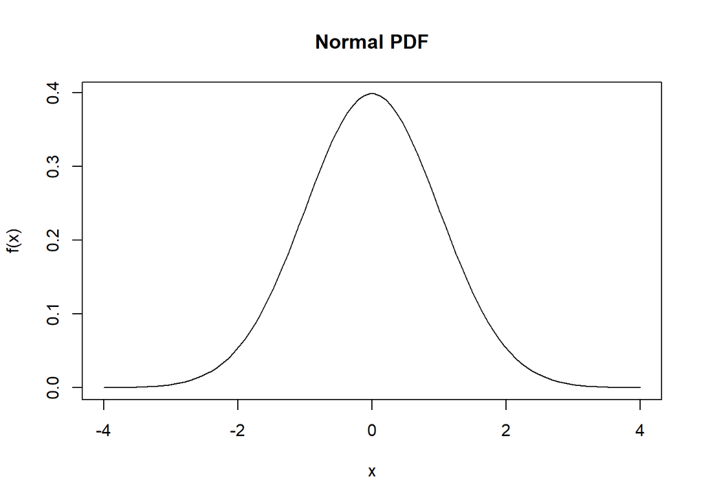

```r
ex2 <- seq(-4, 4, length = 100)
plot(ex2, dnorm(ex2,0,1),xlab = 'x', ylab = 'f(x)', type = 'l', main = 'Normal PDF')
```

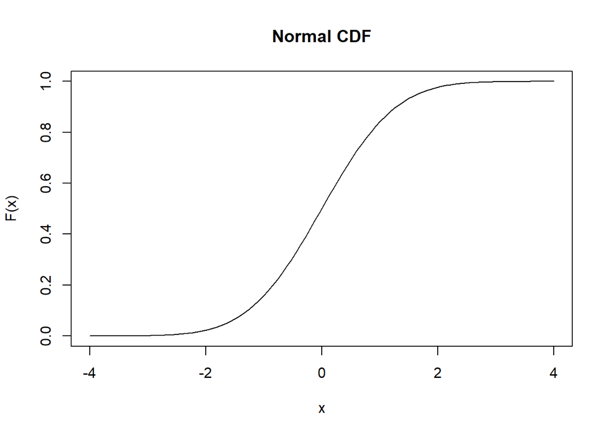

```r
plot(ex2, pnorm(ex2,0,1), xlab = 'x', ylab = 'F(x)', type = 'l', main = 'Normal CDF')
```

```r
# Plotting normal distribution
x <- c(321, 275, 345, 347, 297, 309, 312, 371, 330, 295,
     299, 365, 378, 387, 295, 322, 292, 270, 321, 277)
mean(x)
```

```
## [1] 320.4
```

```r
sd(x)
```

```
## [1] 35.16787
```

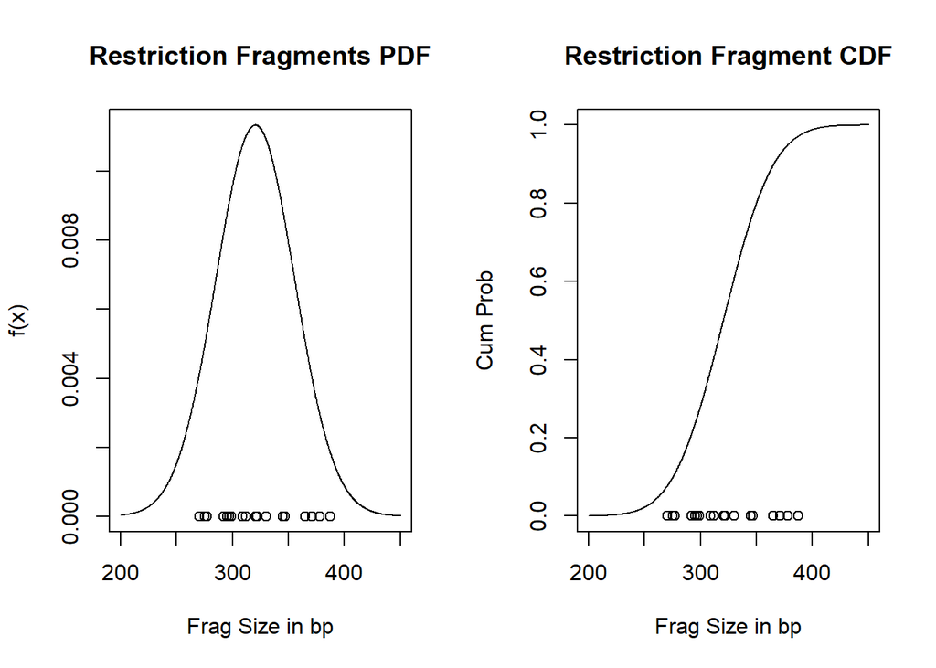

```r
par(mfrow = c(1,2))                               # set space of graph 1x2
ex3 <- seq(200,450,by = .25)
plot(ex3,dnorm(ex3,mean(x),sd(x)),type = 'l',
     xlab = "Frag Size in bp", ylab = "f(x)",  main = "Restriction Fragments PDF")
points(x,rep(0,length(x)))
plot(ex3,pnorm(ex3,mean(x),sd(x)),type = 'l',
     xlab = "Frag Size in bp", ylab = "Cum Prob", main = "Restriction Fragment CDF")
points(x,rep(0,length(x)))
```

```r
par(mfrow = c(1,1))
```

### Example of Normal Distribution I

```r
p1 <- pnorm(600,540,25) - pnorm(500,540,25)
p1
```

```
## [1] 0.9370032
```

### Example of Normal Distribution II

```r
pnorm(825, 750, 50)
```

```
## [1] 0.9331928
```

```r
pnorm(650, 750, 50, lower.tail = FALSE)
```

```
## [1] 0.9772499
```

### Chi-Square Distribution

- x : value
- df : Degree of freedom.
- ncp : Number of observation.
- pseudocode
  - dchisq(x, df, ncp)
    - get pdf value at x where X~chisq(df)
  - pchisq(x, df, ncp, lower.tail=TRUE)
    - get $P(X \leq x)$ where X~chisq(df) if lower.tail=TRUE, otherwise, P(X>x)
  - qchisq(p, df, ncp,lower.tail=TRUE)
    - get x where $P(X \leq x)$=p if lower.tail=TRUE, otherwise P(X>x)= p.
  - rchisq(n, df, ncp)
    - n times observations of X

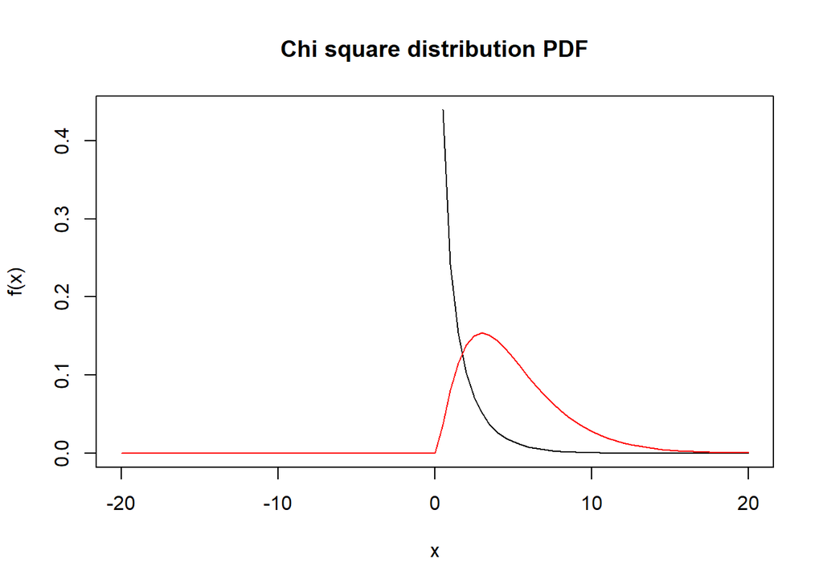

```r
x <- seq(-20,20,by = 0.5)
y <- dchisq(x,df = 1)
plot(x, y, xlab = "x", ylab = "f(x)", type = "l", main = "Chi square distribution PDF")
y <- dchisq(x,df = 5)
lines(x,y,col = "red")
```

```r
pchisq(2,df = 10) #cumulative distribution function
```

```
## [1] 0.003659847
```

```r
pchisq(3,df = 10)
```

```
## [1] 0.01857594
```

```r
1 - pchisq(3,df = 10)
```

```
## [1] 0.9814241
```

```r
pchisq(3,df = 20)
```

```
## [1] 4.097501e-06
```

```r
x = c(2,4,5,6)
pchisq(x,df = 20)
```

```
## [1] 1.114255e-07 4.649808e-05 2.773521e-04 1.102488e-03
```

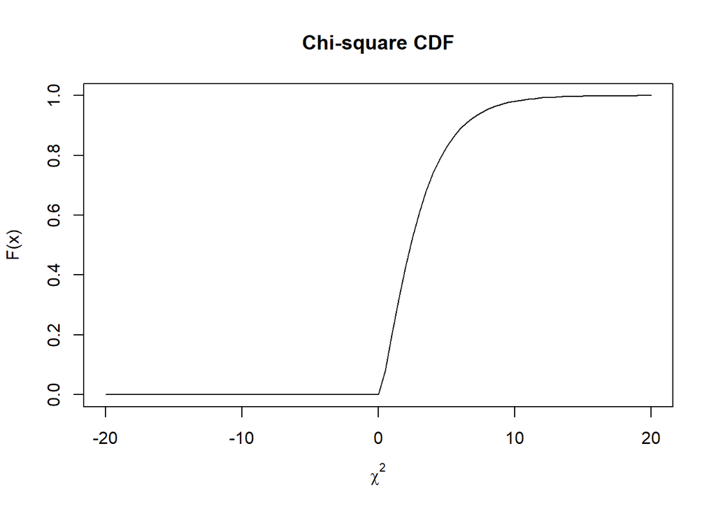

```r
x <- seq(-20,20,by = 0.5)
y <- dchisq(x,df = 1)
plot(x, pchisq(x,3), xlab = expression(chi^2), ylab = "F(x)", type = "l", main = "Chi-square CDF")
```

### Student T-Distribution

- x : value
- df : Degree of freedom.
- ncp : Number of observation.
- pseudocode
  - dt(x, df, ncp)
    - get pdf value at x where X~t(df)
  - pt(x, df, ncp, lower.tail=TRUE)
    - get $P(X \leq x)$ where X~t(df) if lower.tail=TRUE, otherwise, P(X>x)
  - qt(p, df, ncp,lower.tail=TRUE)
    - get x where $P(X \leq x)$=p if lower.tail=TRUE, otherwise P(X>x)= p.
  - rt(n, df, ncp)
    - n times observations of X

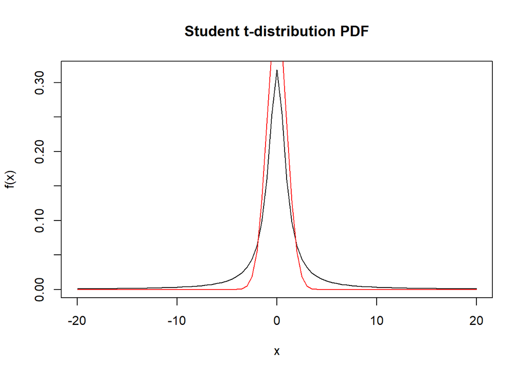

```r
x <- seq(-20,20,by = 0.5)
y <- dt(x,df = 1)
plot(x, y, xlab = "x", ylab = "f(x)", type = "l", main = "Student t-distribution PDF")
y <- dt(x,df = 100)
lines(x,y,col = "red")
```

```r
# Find the 2.5th and 97.5th percentiles of the Student t distribution with 5 degrees of freedom
qt(c(.025, .975), df = 5)   # 5 degrees of freedom
```

```
## [1] -2.570582  2.570582
```

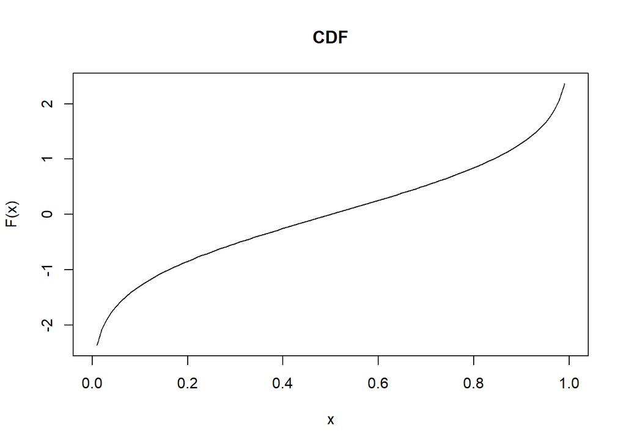

```r
# Draw cumulative density function of Student t-distribution on your own. (Use qt() function)
curve(qt(x, 100), xlab = 'x', ylab = "F(x)", main = "CDF")
```

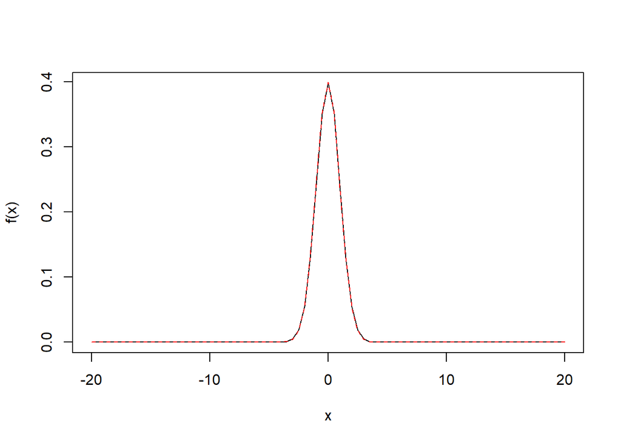

```r
# Plot and compare probability density function of standard normal distribution
# and student t-distribution with some values of degree of freedom yourself.
# (dnorm(), dt(), ...)

plot(x, dt(x,df = 100), xlab = "x", ylab = "f(x)", type = "l")
lines(x, dnorm(x), lty = 2, col = "red", cex = 0.8)
```

### Problem - 1

```r
#1-A
pnorm(32,40,6.3,lower.tail = FALSE)
```

```
## [1] 0.8979294
```

```r
#1-B
pnorm(27,40,6.3,lower.tail = TRUE)
```

```
## [1] 0.01953295
```

```r
#1-C
pnorm(49,40,6.3) - pnorm(37,40,6.3)
```

```
## [1] 0.6064669
```

### Problem - 2

The serum cholesterol level X in 14-year old boys has approximately a normal distribution with mean 170 and standard deviation 30. - A. Find the probability that the serum cholesterol level of a randomly chosen 14-year-old boy exceeds 230. - B. In a middle school, there are 300 14-year-old boys. Find the probability that at least 8 boys have a serum cholesterol level that exceeds 230. Use proper normal approximation technique.

```r
#2-A
P2 <- pnorm(230,170,30,lower.tail = FALSE)

#2-B
Numb <- pnorm(8 - 0.5,300*P2,sqrt(300*P2*(1 - P2)),lower.tail = FALSE)
```

### Problem - 3

The average rate of distilled water usage (liters per day) by a laboratory is known to involve the lognormal distribution with parameters $\mu$=5 and $\sigma$=2. It is important for planning purposes to get a sense of periods of high usage. - A. Draw the probability density function of water usage rate for given situation. - B. What is the probability that, for any given day, more than 50 liters of water are used? - C. What is the mean of the average water usage per day in liters?

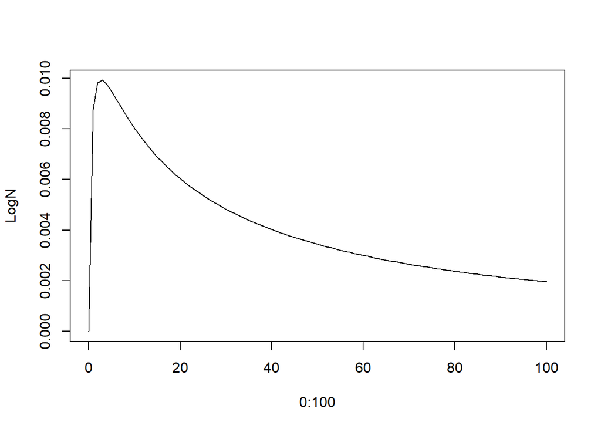

```r
#3-A
LogN <- dlnorm(0:100,5,2)
plot(0:100,LogN,type = 'l')
```

```r
#3-B
P3 <- plnorm(50,5,2,lower.tail = FALSE)

#3-C
AVG <- exp(5 + (2^2)/2)
```